# Data Analysis Assignment #1 (50 points total)

Quiballo, Kagen

Submit both the .Rmd and .html files for grading. You may remove the instructions and example problem above, but do not remove the YAML metadata block or the first, “setup” code chunk. Address the steps that appear below and answer all the questions. Be sure to address each question with code and comments as needed. You may use either base R functions or ggplot2 for the visualizations.

The following code chunk will:

1. load the “ggplot2”, “gridExtra” and “knitr” packages, assuming each has been installed on your machine,
2. read-in the abalones dataset, defining a new data frame, “mydata,”
3. return the structure of that data frame, and
4. calculate new variables, VOLUME and RATIO.

Do not include package installation code in this document. Packages should be installed via the Console or ‘Packages’ tab. You will also need to download the abalones.csv from the course site to a known location on your machine. Unless a *file.path()* is specified, R will look to directory where this .Rmd is stored when knitting.

```
## 'data.frame':    1036 obs. of  8 variables:
##  $ SEX   : Factor w/ 3 levels "F","I","M": 2 2 2 2 2 2 2 2 2 2 ...
##  $ LENGTH: num  5.57 3.67 10.08 4.09 6.93 ...
##  $ DIAM  : num  4.09 2.62 7.35 3.15 4.83 ...
##  $ HEIGHT: num  1.26 0.84 2.205 0.945 1.785 ...
##  $ WHOLE : num  11.5 3.5 79.38 4.69 21.19 ...
##  $ SHUCK : num  4.31 1.19 44 2.25 9.88 ...
##  $ RINGS : int  6 4 6 3 6 6 5 6 5 6 ...
##  $ CLASS : Factor w/ 5 levels "A1","A2","A3",..: 1 1 1 1 1 1 1 1 1 1 ...
```

### Test Items starts from here - There are 6 sections - Total 50 points

*##### Section 1: (6 points) Summarizing the data.*

(1)(a) (1 point) Use *summary()* to obtain and present descriptive statistics from mydata. Use *table()* to present a frequency table using CLASS and RINGS. There should be 115 cells in the table you present.

```
##  SEX         LENGTH           DIAM            HEIGHT          WHOLE
##  F:326   Min.   : 2.73   Min.   : 1.995   Min.   :0.525   Min.   :  1.625
##  I:329   1st Qu.: 9.45   1st Qu.: 7.350   1st Qu.:2.415   1st Qu.: 56.484
##  M:381   Median :11.45   Median : 8.925   Median :2.940   Median :101.344
##          Mean   :11.08   Mean   : 8.622   Mean   :2.947   Mean   :105.832
##          3rd Qu.:13.02   3rd Qu.:10.185   3rd Qu.:3.570   3rd Qu.:150.319
##          Max.   :16.80   Max.   :13.230   Max.   :4.935   Max.   :315.750
##      SHUCK              RINGS        CLASS        VOLUME
##  Min.   :  0.5625   Min.   : 3.000   A1:108   Min.   :  3.612
##  1st Qu.: 23.3006   1st Qu.: 8.000   A2:236   1st Qu.:163.545
##  Median : 42.5700   Median : 9.000   A3:329   Median :307.363
##  Mean   : 45.4396   Mean   : 9.993   A4:188   Mean   :326.804
##  3rd Qu.: 64.2897   3rd Qu.:11.000   A5:175   3rd Qu.:463.264
##  Max.   :157.0800   Max.   :25.000            Max.   :995.673
##      RATIO
##  Min.   :0.06734
##  1st Qu.:0.12241
##  Median :0.13914
##  Mean   :0.14205
##  3rd Qu.:0.15911
##  Max.   :0.31176
```

```
##
##        3   4   5   6   7   8   9  10  11  12  13  14  15  16  17  18  19  20
##   A1   9   8  24  67   0   0   0   0   0   0   0   0   0   0   0   0   0   0
##   A2   0   0   0   0  91 145   0   0   0   0   0   0   0   0   0   0   0   0
##   A3   0   0   0   0   0   0 182 147   0   0   0   0   0   0   0   0   0   0
##   A4   0   0   0   0   0   0   0   0 125  63   0   0   0   0   0   0   0   0
##   A5   0   0   0   0   0   0   0   0   0   0  48  35  27  15  13   8   8   6
##
##       21  22  23  24  25
##   A1   0   0   0   0   0
##   A2   0   0   0   0   0
##   A3   0   0   0   0   0
##   A4   0   0   0   0   0
##   A5   4   1   7   2   1
```

**Question (1 point): Briefly discuss the variable types and distributional implications such as potential skewness and outliers.**

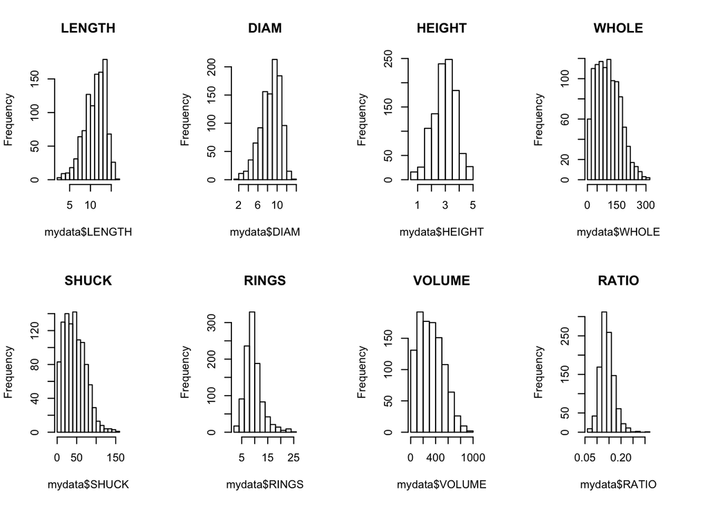

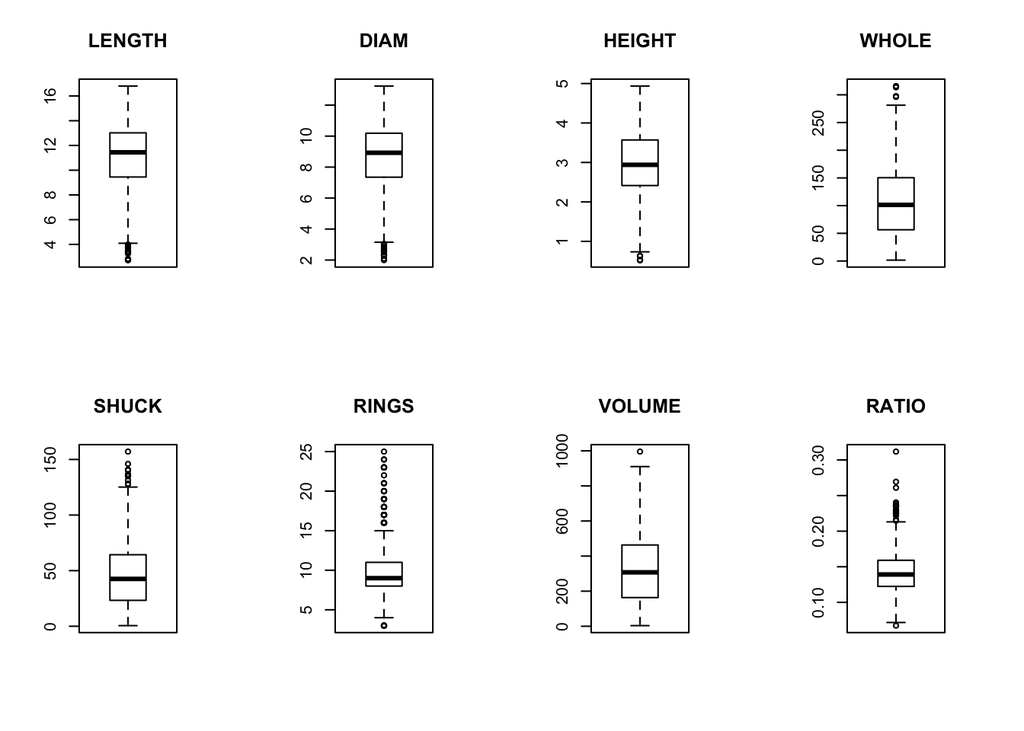

*Answer: There are 10 variables in the dataset. LENGTH, DIAM, HEIGHT, WHOLE, SHUCK, RINGS, VOLUME, and RATIO are numeric variables. SEX is a nominal variable, and CLASS is a ordinal variable. The variables with that are possibly skewed left are LENGTH, DIAM, HEIGHT. The variables that are possibly skewed right are WHOLE, SHUCK, RINGS, VOLUME, and RATIO as indicated in the respective histograms. All variables appear to have outliers as indicated in the respective boxplots.*

(1)(b) (1 point) Generate a table of counts using SEX and CLASS. Add margins to this table (Hint: There should be 15 cells in this table plus the marginal totals. Apply *table()* first, then pass the table object to *addmargins()* (Kabacoff Section 7.2 pages 144-147)). Lastly, present a barplot of these data; ignoring the marginal totals.

```
##
##         A1   A2   A3   A4   A5  Sum
##   F      5   41  121   82   77  326
##   I     91  133   65   21   19  329
##   M     12   62  143   85   79  381
##   Sum  108  236  329  188  175 1036
```

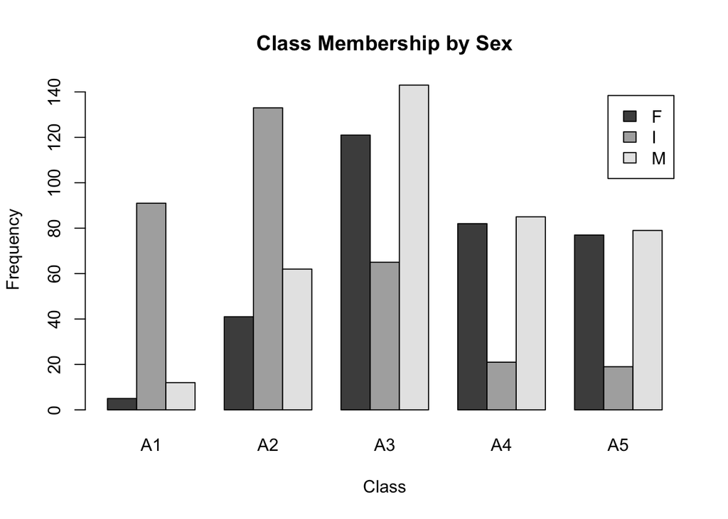

**Essay Question (2 points): Discuss the sex distribution of abalones. What stands out about the distribution of abalones by CLASS?**

*Answer: Looking at the table, there is relatively the same amount of all 3 sexes recorded. Male (381) has slightly more records than Female (326) or infant (329). Looking at the barplot, it appears that class A3 has the most records and class A1 has the least. A1 and A2 are comprised mostly of infant, and A3, A4, and A5 are comprised mostly of Male and Female.*

(1)(c) (1 point) Select a simple random sample of 200 observations from “mydata” and identify this sample as “work.” Use *set.seed(123)* prior to drawing this sample. Do not change the number 123. Note that *sample()* “takes a sample of the specified size from the elements of x.” We cannot sample directly from “mydata.” Instead, we need to sample from the integers, 1 to 1036, representing the rows of “mydata.” Then, select those rows from the data frame (Kabacoff Section 4.10.5 page 87).

Using “work”, construct a scatterplot matrix of variables 2-6 with *plot(work[, 2:6])* (these are the continuous variables excluding VOLUME and RATIO). The sample “work” will not be used in the remainder of the assignment.

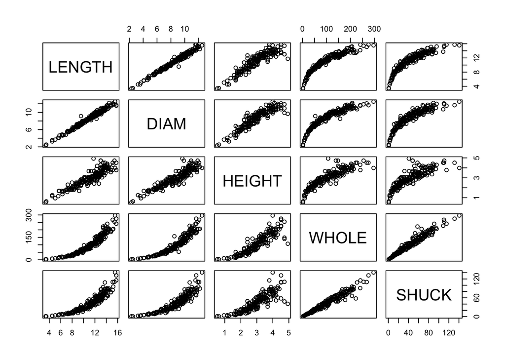

*##### Section 2: (5 points) Summarizing the data using graphics.*

(2)(a) (1 point) Use “mydata” to plot WHOLE versus VOLUME. Color code data points by CLASS.

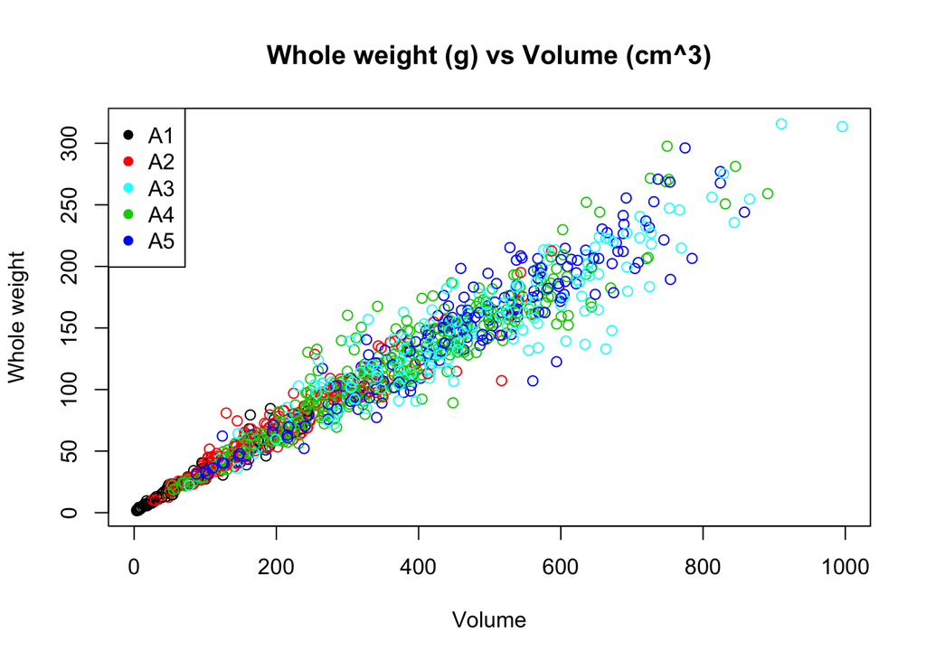

(2)(b) (2 points) Use “mydata” to plot SHUCK versus WHOLE with WHOLE on the horizontal axis. Color code data points by CLASS. As an aid to interpretation, determine the maximum value of the ratio of SHUCK to WHOLE. Add to the chart a straight line with zero intercept using this maximum value as the slope of the line. If you are using the ‘base R’ *plot()* function, you may use *abline()* to add this line to the plot. Use *help(abline)* in R to determine the coding for the slope and intercept arguments in the functions. If you are using ggplot2 for visualizations, *geom_abline()* should be used.

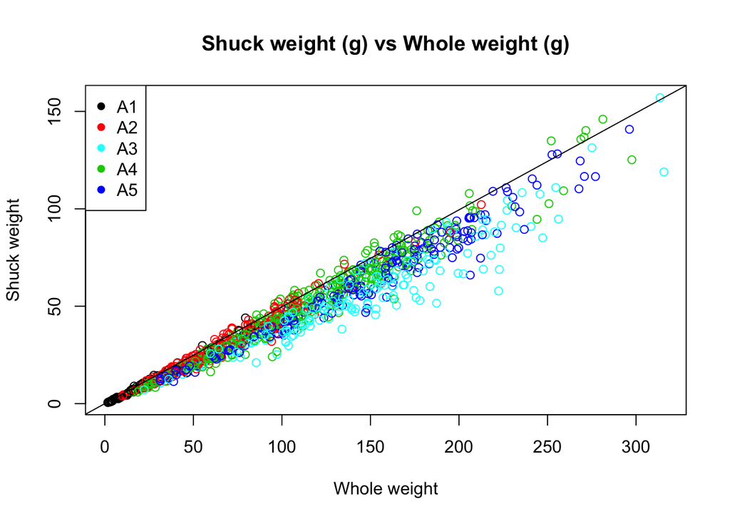

**Essay Question (2 points): How does the variability in this plot differ from the plot in (a)? Compare the two displays. Keep in mind that SHUCK is a part of WHOLE. Consider the location of the different age classes.**

```
## [1] 0.967717
```

```
## [1] 0.9734693
```

*Answer: It appears that there is more variability in the WHOLE versus VOLUME plot and less variability in the SHUCK versus WHOLE plot. This is confirmed with the slightly weaker correlation between VOLUME and WHOLE. Both plots have a strong, positive, linear association between the two variables. Because SHUCK is part of WHOLE, it is logical that SHUCK has a stronger correlation (and less variability) with WHOLE than VOLUME does with WHOLE. Additionally, the age classes indicate that lower classes (A1 and A2) have smaller values of WHOLE, SHUCK, and VOLUME, whereas higher age classes (A3, A4, A5) have higher values.*

*### Section 3: (8 points) Getting insights about the data using graphs.*

(3)(a) (2 points) Use “mydata” to create a multi-figured plot with histograms, boxplots and Q-Q plots of RATIO differentiated by sex. This can be done using *par(mfrow = c(3,3))* and base R or *grid.arrange()* and ggplot2. The first row would show the histograms, the second row the boxplots and the third row the Q-Q plots. Be sure these displays are legible.

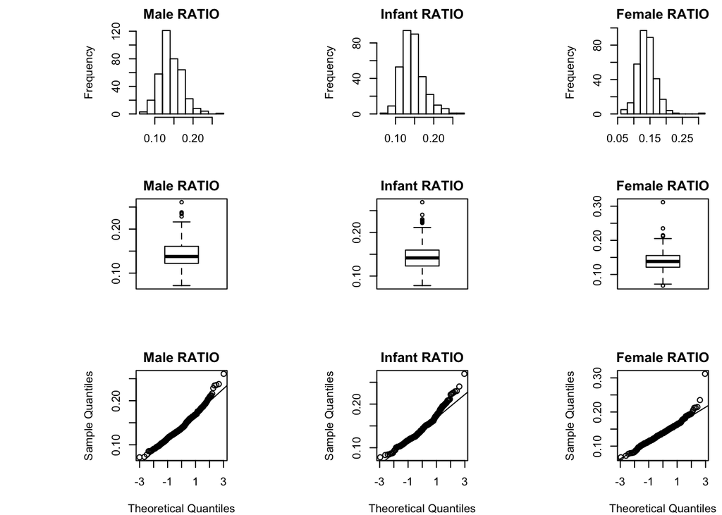

**Essay Question (2 points): Compare the displays. How do the distributions compare to normality? Take into account the criteria discussed in the sync sessions to evaluate non-normality.**

*Answer: From the histograms, it appears that all distributions are approximately normal with a perhaps a slight skew right indicated by the tails of the distribution. Similarly, the boxplots indicate an approximately normal distribution with medians aproximately equidistant from Q1 and Q3. The QQ plots are approximately linear indicated by the straight lines. However, the distribution of females does have an outlier with a significantly larger RATIO.*

(3)(b) (2 points) The boxplots in (3)(a) indicate that there are outlying RATIOs for each sex. *boxplot.stats()* can be used to identify outlying values of a vector. Present the abalones with these outlying RATIO values along with their associated variables in “mydata”. Display the observations by passing a data frame to the kable() function. Basically, we want to output those rows of “mydata” with an outlying RATIO, but we want to determine outliers looking separately at infants, females and males.

|  | SEX | LENGTH | DIAM | HEIGHT | WHOLE | SHUCK | RINGS | CLASS | VOLUME | RATIO |
| --- | --- | --- | --- | --- | --- | --- | --- | --- | --- | --- |
| 3 | I | 10.080 | 7.350 | 2.205 | 79.37500 | 44.00000 | 6 | A1 | 163.364040 | 0.2693371 |
| 37 | I | 4.305 | 3.255 | 0.945 | 6.18750 | 2.93750 | 3 | A1 | 13.242072 | 0.2218308 |
| 42 | I | 2.835 | 2.730 | 0.840 | 3.62500 | 1.56250 | 4 | A1 | 6.501222 | 0.2403394 |
| 58 | I | 6.720 | 4.305 | 1.680 | 22.62500 | 11.00000 | 5 | A1 | 48.601728 | 0.2263294 |
| 67 | I | 5.040 | 3.675 | 0.945 | 9.65625 | 3.93750 | 5 | A1 | 17.503290 | 0.2249577 |
| 89 | I | 3.360 | 2.310 | 0.525 | 2.43750 | 0.93750 | 4 | A1 | 4.074840 | 0.2300704 |
| 105 | I | 6.930 | 4.725 | 1.575 | 23.37500 | 11.81250 | 7 | A2 | 51.572194 | 0.2290478 |
| 200 | I | 9.135 | 6.300 | 2.520 | 74.56250 | 32.37500 | 8 | A2 | 145.027260 | 0.2232339 |
| 350 | F | 7.980 | 6.720 | 2.415 | 80.93750 | 40.37500 | 7 | A2 | 129.505824 | 0.3117620 |
| 379 | F | 15.330 | 11.970 | 3.465 | 252.06250 | 134.89812 | 10 | A3 | 635.827846 | 0.2121614 |
| 420 | F | 11.550 | 7.980 | 3.465 | 150.62500 | 68.55375 | 10 | A3 | 319.365585 | 0.2146560 |
| 421 | F | 13.125 | 10.290 | 2.310 | 142.00000 | 66.47062 | 9 | A3 | 311.979938 | 0.2130606 |
| 458 | F | 11.445 | 8.085 | 3.150 | 139.81250 | 68.49062 | 9 | A3 | 291.478399 | 0.2349767 |
| 586 | F | 12.180 | 9.450 | 4.935 | 133.87500 | 38.25000 | 14 | A5 | 568.023435 | 0.0673388 |
| 746 | M | 13.440 | 10.815 | 1.680 | 130.25000 | 63.73125 | 10 | A3 | 244.194048 | 0.2609861 |
| 754 | M | 10.500 | 7.770 | 3.150 | 132.68750 | 61.13250 | 9 | A3 | 256.992750 | 0.2378764 |
| 803 | M | 10.710 | 8.610 | 3.255 | 160.31250 | 70.41375 | 9 | A3 | 300.153640 | 0.2345924 |
| 810 | M | 12.285 | 9.870 | 3.465 | 176.12500 | 99.00000 | 10 | A3 | 420.141472 | 0.2356349 |
| 852 | M | 11.550 | 8.820 | 3.360 | 167.56250 | 78.27187 | 10 | A3 | 342.286560 | 0.2286735 |

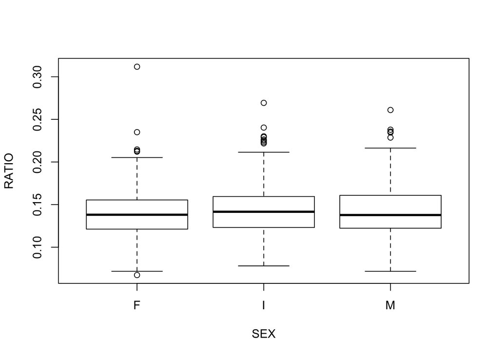

**Essay Question (2 points): What are your observations regarding the results in (3)(b)?**

*### Section 4: (8 points) Getting insights about possible predictors.*

(4)(a) (3 points) With “mydata,” display side-by-side boxplots for VOLUME and WHOLE, each differentiated by CLASS There should be five boxes for VOLUME and five for WHOLE. Also, display side-by-side scatterplots: VOLUME and WHOLE versus RINGS. Present these four figures in one graphic: the boxplots in one row and the scatterplots in a second row. Base R or ggplot2 may be used.

[figure not shown]

**Essay Question (5 points) How well do you think these variables would perform as predictors of age? Explain.**

*Answer: Looking at VOLUME and WHOLE, It appears that age classes A1 and A2 have significantly lower values than A3, A4, and A5. However, the differences between the higher age classes would be more difficult to distinguish from each other. VOLUME and WHOLE would be decent predictors of AGE, but if AGE were to be split into 2 ordinal variables (young = A1 & A2; old= A3, A4, & A5), then VOLUME and WHOLE would be much better predictors. This can also be seen in the scatterplot where the first 2 age classes (by color) are lower than the higher 3 age classes. There is a weak, positive correlation betweek VOLUME & RINGS and WHOLE & RINGS.*

*### Section 5: (12 points) Getting insights regarding different groups in the data.*

(5)(a) (2 points) Use *aggregate()* with “mydata” to compute the mean values of VOLUME, SHUCK and RATIO for each combination of SEX and CLASS. Then, using *matrix()*, create matrices of the mean values. Using the “dimnames” argument within *matrix()* or the *rownames()* and *colnames()* functions on the matrices, label the rows by SEX and columns by CLASS. Present the three matrices (Kabacoff Section 5.6.2, p. 110-111). The *kable()* function is useful for this purpose. You do not need to be concerned with the number of digits presented.

Mean Volume

|  | A1 | A2 | A3 | A4 | A5 |
| --- | --- | --- | --- | --- | --- |
| F | 255.29938 | 276.8573 | 412.6079 | 498.0489 | 486.1525 |
| I | 66.51618 | 160.3200 | 270.7406 | 316.4129 | 318.6930 |
| M | 103.72320 | 245.3857 | 358.1181 | 442.6155 | 440.2074 |

Mean Shuck

|  | A1 | A2 | A3 | A4 | A5 |
| --- | --- | --- | --- | --- | --- |
| F | 38.90000 | 42.50305 | 59.69121 | 69.05161 | 59.17076 |
| I | 10.11332 | 23.41024 | 37.17969 | 39.85369 | 36.47047 |
| M | 16.39583 | 38.33855 | 52.96933 | 61.42726 | 55.02762 |

Mean Ratio

|  | A1 | A2 | A3 | A4 | A5 |
| --- | --- | --- | --- | --- | --- |
| F | 0.1546644 | 0.1554605 | 0.1450304 | 0.1379609 | 0.1233605 |
| I | 0.1569554 | 0.1475600 | 0.1372256 | 0.1244413 | 0.1167649 |
| M | 0.1512698 | 0.1564017 | 0.1462123 | 0.1364881 | 0.1262089 |

(5)(b) (3 points) Present three graphs. Each graph should include three lines, one for each sex. The first should show mean RATIO versus CLASS; the second, mean VOLUME versus CLASS; the third, mean SHUCK versus CLASS. This may be done with the ‘base R’ *interaction.plot()* function or with ggplot2 using *grid.arrange()*.

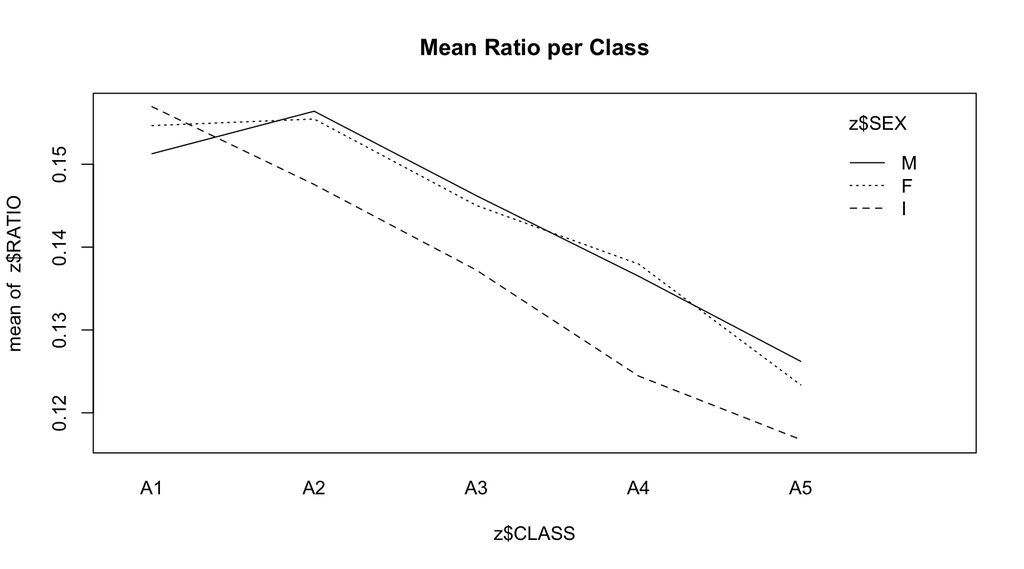

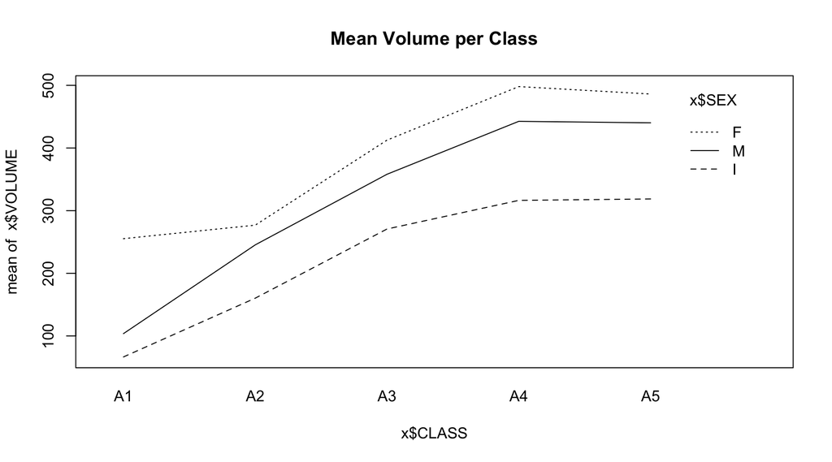

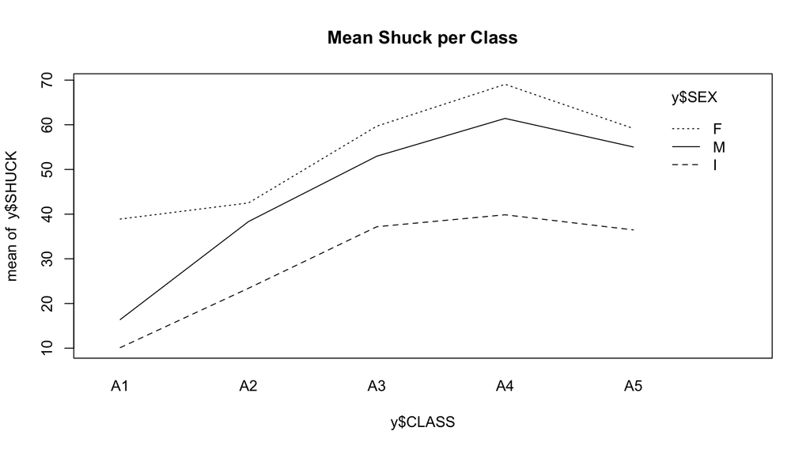

**Essay Question (2 points): What questions do these plots raise? Consider aging and sex differences.**

5(c) (3 points) Present four boxplots using *par(mfrow = c(2, 2)* or *grid.arrange()*. The first line should show VOLUME by RINGS for the Infants and, separately, for the adult; factor levels “M” and “F,” combined. The second line should show WHOLE by RINGS for the Infants and, separately, for the adults. Since the data are sparse beyond 15 rings, limit the displays to less than 16 rings. One way to accomplish this is to generate a new data set using subset() to select RINGS < 16. Use ylim = c(0, 1100) for VOLUME and ylim = c(0, 400) for WHOLE. If you wish to reorder the displays for presentation purposes or use ggplot2 go ahead.

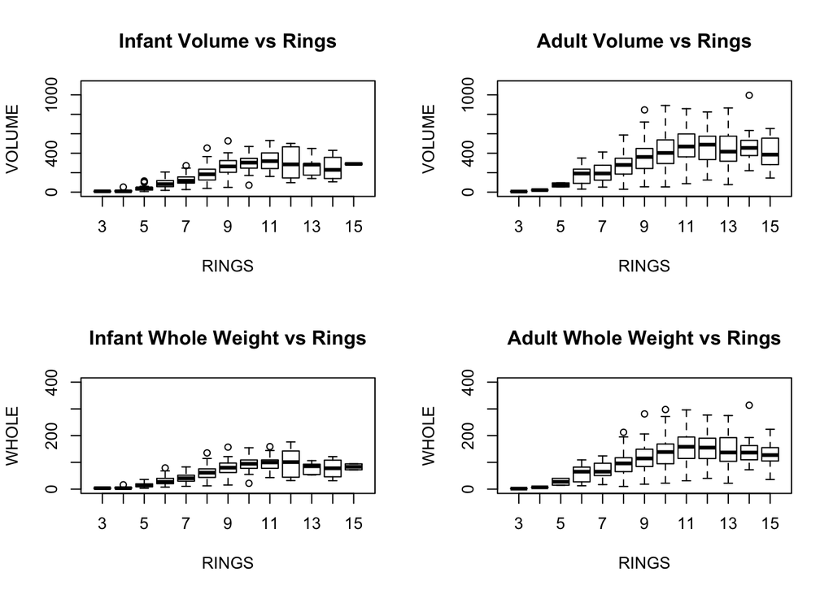

**Essay Question (2 points): What do these displays suggest about abalone growth? Also, compare the infant and adult displays. What differences stand out?**

*Answer: Both infants and adults have increasing mean values of VOLUME and WHOLE as RINGS increases from 3 to 11. Adults however tend to have a much larger increase in VOLUME or WHOLE values. As RINGS increases from 11 to 15, the value of VOLUME and WHOLE for both infants and adults tends to level out and possibly even decrease slighty. These plots suggest that adults grow quicker than infants with the same amount of RINGS.*

*### Section 6: (11 points) Conclusions from the Exploratory Data Analysis (EDA).*

**Conclusions**

**Essay Question 1) (5 points) Based solely on these data, what are plausible statistical reasons that explain the failure of the original study? Consider to what extent physical measurements may be used for age prediction.**

*Answer: The first point to make would be the presence of outliers. From the first visuals of histograms and boxplots, each variable is slightly skewed by the presence of outliers, making the distributions less normally distributed. By ruling out abalones that may be outliers, predictions may be more accurate. Another point to make is the creation of new variables using old data. Any interaction between the two may pose a problem due to multicollinearity of variables. They essentially provide the same information in different formats. Next, the way data is collected for sex should not include infant as a category. How this is determined is unknown, but there are already 2 age variables (Class and rings) that can indicate the maturity of an abalone that Sex should not account for. Lastly, the study fails to collect any information about the environment that these abalones lived in. Different climates and temperatures may yield different mean measurements for abalones, as this organism is a product of the environment it lives in.*

**Essay Question 2) (3 points) Do not refer to the abalone data or study. If you were presented with an overall histogram and summary statistics from a sample of some population or phenomenon and no other information, what questions might you ask before accepting them as representative of the sampled population or phenomenon?**

*Answer: What is the sample size? A larger sample size may be more representative of the population. Are there outliers? These can be identified by looking at the extrema statistics. Is the sample normally distributed and approximately symmetrical? Are the mean and median similar or does the difference indicate skewness? Is a large standard deviation indicative of a large spread of data, or does a smaller variance indicate higher precision in the sample? How was the data collected? (Preferably a random sample to be more reliable and representative)? What biases may have resulted from data collection methods that are non-random?*

**Essay Question 3) (3 points) Do not refer to the abalone data or study. What do you see as difficulties analyzing data derived from observational studies? Can causality be determined? What might be learned from such studies?**

*Answer: From observational studies, it is difficult to find any reason behind correlations without speculation. Causality can never be determined from an observational study unless there is experimentation. Observational studies would need to control all variables (which by definition would be an experient, not an observational study). Correlations may provide interesting insights but should never be used to conclude causal relationships. Such a study may propose ideas and questions as to why a correlation is present for following experiments to prove causation from discovered correlations.*